# Literature Review

Sources, Topical, Chronological, General-to-Specific Lit. Reviews

Bogdan G. Popescu

bogdan.popescu@johncabot.edu

John Cabot University

## Literature Review

1. **What Is a Literature Review?**
2. **What Counts as Literature?**
3. **How to Do a Literature Review**
4. **Step 1: Finding Sources**
5. **Step 2: Reading Strategically**
6. **Step 3: Synthesizing and Organizing**
7. **Step 4: Identifying the Gap and Contribution**
8. **Step 5: Explaining Your Rationale**

## Literature Review

### What it is?

Literature Review - synthesis of the research previously done on a topic

- gives background for your study and helps show what your research will add (how it will address weaknesses of existing studies)
- shows that the question has been answered in a limited or flawed way
- could point out what scholars disagree about
- develops an argument about what needs to be done to provide a better answer.

The literature review is not just a summary of the previous literature. It is also a critical analysis of the literature

The literature review is also an iterative process: you can go back to it even after you write your conclusion and findings.

## Literature Review

### What Counts as Literature

What counts as literature include:

- articles in peer-reviewed journals
- books

What does not count as scholarly literature

- blog posts
- news articles
- opinion pieces

## Literature Review

### How to do a Literature Review

1. Search the Relevant Literature on Google Scholar: pick credible sources (peer-reviewed journals and academic books)
2. Evaluate sources
3. Organize: Identify themes, debates
4. Identify the gaps, what is missing or contradictory
5. Outline the structure of the literature review
6. Write your literature review in context

**Note**

search → read → synthesize → gap → write

## Literature Review

### How to Take Notes

For all the articles and chapters that you read, complete an excel spreadsheet with the following columns:

- Citation
- Question
- Methods
- Findings
- Gap

Remember to always cite ideas that are not your own, even when paraphrasing

## Literature Review

### Step 1: Finding Sources

1. Identify key terms and related concepts based on your research question.
2. Combine terms strategically in Google Scholar (e.g., “gender quotas” AND “political speech”).
3. Prioritize sources with relevant titles and strong citation counts.
4. Save useful PDFs using a clear naming convention (e.g., “barnes_2020_gender_quotas_speech.pdf”) and organize them in a designated folder.
5. If search results are too broad or irrelevant, refine your terms or test alternative combinations (e.g., “political speech gender”).

**Example**  
Research Question: *Do women become more aggressive in political speech after gender quotas?*

Start with:  
- “gender quotas”  
Then refine to:  
- “gender quotas political speech”  
- “political speech gender”

## Literature Review

### Step 1: Finding Sources: Example

Your folder should look like this.

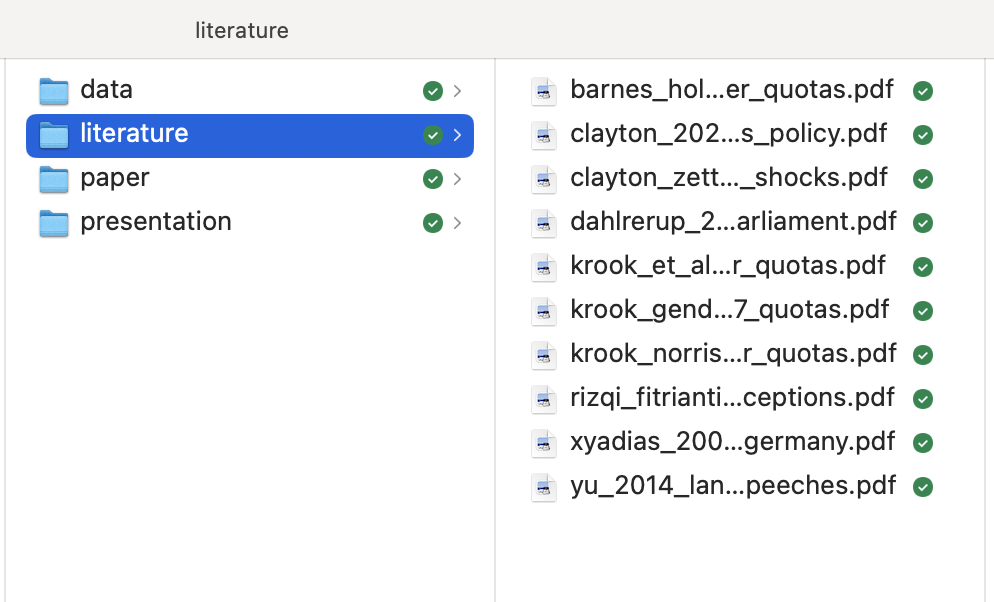

## Literature Review

### Step 1: Finding Sources: Tips

If you cannot find some pdf go to “bing.com” and type the name of the paper and the authors and add pdf

You may be able to find the article this way.

## Literature Review

### Step 2: Reading Strategically Homework 1

Now that you’ve found your sources, let’s talk about how to read them efficiently.

Read at least 3 key articles in full.

For the others, skim strategically — focus on the abstract, introduction, and conclusion, as well as any sections directly relevant to your topic.

For each article, answer:

1. What is the author’s central research question?
2. What key factors or variables does the analysis highlight?
3. What assumptions underpin the argument?
4. What methods and evidence are used to support the claims?
5. What are the article’s key insights or implications for your research question?
6. What other relevant sources does the article cite? (Note them: Author, Year)
7. How does this article’s argument differ from others you’ve read?

## Literature Review

### Step 2: Reading Strategically Homework 1 Example

**Article** barnes_holmes_2020_gender_quotas.pdf

**Central Question**  
Do gender quotas increase not only women’s numeric representation but also the overall personal and professional diversity of legislators?

**Factors Highlighted in the Analysis**  
- Time since quota adoption  
- Women’s share in legislature  
- Party recruitment patterns  
- Legislative turnover  
- Disruption of gendered norms in candidate selection

## Literature Review

### Step 2: Reading Strategically Homework 1 Example

**Assumptions Behind the Argument**  
- Quotas can redefine what qualifies someone as a viable political candidate  
- Political parties rely on insular, gendered networks  
- Greater diversity benefits democratic representation and legitimacy

**Methods and Evidence Used**  
- Quantitative analysis of 1,700+ legislators across 10 Argentinian provincial chambers over time  
- Creation of diversity indexes using biographical data  
- Qualitative evidence from elite interviews

## Literature Review

### Step 2: Reading Strategically Homework 1 Example

**Insights on Gender Quotas and Political Speech**  
An implication that increasing diversity through quotas may reshape legislative priorities and norms.

**Other Relevant Citations**  
- Alexander, 2012  
- Holman and Schneider, 2018  
- Crowder-Meyer, 2013  
- Clayton and Zetterberg, 2018  
- Murray, 2014  
- Franceschet and Piscopo, 2014

## Literature Review

### Step 3: Synthesizing and Organizing - Topical Organizing

You can organize your literature review by topic

- emphasize the different related issues about the topic

**Best for**: When the field has multiple competing or complementary strands.

- thus, it helps synthesize across studies;

## Literature Review Organization

### Step 3: Synthesizing and Organizing - Topical Organizing

**Intro**

“Scholars have long debated the causes of voter turnout. The literature can be divided into three main themes: institutional factors, socioeconomic variables, and psychological motivations.”

**Body Paragraphs (by theme)**:

1. **Institutional Factors**

Studies such as Powell (1986) and Blais (2006) emphasize how electoral systems and compulsory voting laws shape turnout rates…

2. **Socioeconomic Variables**

A second body of work focuses on individual-level characteristics such as education and income (Verba et al. 1995)…

3. **Psychological Motivations**

Finally, researchers point to internal political efficacy and civic duty as predictors (Campbell et al. 1960)…

## Literature Review Organization

### Step 3: Synthesizing and Organizing - Topical Organizing

**Intro**

“Scholars have long debated the causes of voter turnout. The literature can be divided into three main themes: institutional factors, socioeconomic variables, and psychological motivations.”

**Conclusion**

While each theme contributes to our understanding of turnout, few studies integrate these perspectives, leaving open questions about how institutions and individual-level motivations interact.

## Literature Review Organization

### Step 3: Synthesizing and Organizing - Chronological Organizing

You can also organize your literature review chronologically.

If you identify themes in time, you can organize your literature review with come chronology in mind

**Best for**: Showing how ideas, debates, or methods evolved over time.

## Literature Review Organization

### Step 3: Synthesizing and Organizing - Chronological Organizing

**Intro**

“Theories of nationalism have evolved over time, moving from primordialist to constructivist perspectives.”

**Body Paragraphs (by time period)**:

1. **Early Approaches (1940s–1960s)**

Primordialist views, such as those of Geertz (1963), saw nationalism as rooted in ancient loyalties…

2. **Modernist Turn (1970s–1990s)**

Anderson (1983), Gellner (1983), and Hobsbawm (1990) emphasized the role of industrialization and print capitalism…

3. **Constructivist and Post-Structuralist Approaches (2000s–Present)**

More recent work highlights the performativity and discursive nature of nationalism (Brubaker 2004)…

## Literature Review Organization

### Step 3: Synthesizing and Organizing - Chronological Organizing

**Intro**

“Theories of nationalism have evolved over time, moving from primordialist to constructivist perspectives.”

**Conclusion**

The field has increasingly shifted toward fluid, socially constructed accounts, though debate remains over the role of historical continuity.

## Literature Review Organization

### Step 3: Synthesizing and Organizing - General-to-Specific Organizing

You can organize the literature review by focusing on general things and then, more on the specific debates

This allows to clearly show the gap in previous research.

## Literature Review Organization

### Step 3: Synthesizing and Organizing - General-to-Specific Organizing Example

**Intro**

“Why do some authoritarian regimes survive mass protests while others collapse? Existing literature provides partial answers but leaves important gaps.”

**Body Paragraphs**:

1. **Broad Context:**

Scholars have studied democratization broadly (Przeworski et al. 2000)…

2. **Narrowing Focus:**

More recent work focuses on protest outcomes in authoritarian contexts (Chenoweth & Stephan 2011)…

3. **Specific Debate:**

Some argue elite cohesion is key (Slater 2010), others stress economic shocks (Acemoglu et al. 2013)…

## Literature Review Organization

### Step 3: Synthesizing and Organizing - General-to-Specific Organizing Example

**Intro**

“Why do some authoritarian regimes survive mass protests while others collapse? Existing literature provides partial answers but leaves important gaps.”

4. **Gap**

However, few studies examine the interaction between protest tactics and regime type.

## Literature Review Organization

### Step 3: Synthesizing and Organizing - General-to-Specific Organizing Example

**Intro**

“Why do some authoritarian regimes survive mass protests while others collapse? Existing literature provides partial answers but leaves important gaps.”

**Conclusion**

This study addresses that gap by analyzing how digital mobilization strategies vary by authoritarian institutional structure.

## Literature Review

### Gap, Contribution, and Rationale

The additional elements that need to be included in the literature review are:

- **Gap and Contribution** - What’s missing in the literature and What new insight you are offering?
- **Rationale** - Why you’re doing the project

## Literature Review

### Step 4: Identifying the Gap and Contribution

Your literature review should conclude by identifying:

- What the literature has overlooked (concepts, data, arguments)
- Why this gap exists (blind spots, assumptions, lack of data, etc.)
- Why it matters (theoretical, empirical, or practical consequences)

You can frame the gap as something that has not been done and should complement existing work rather than aggressively criticize it. Keep in mind: the authors you’re critiquing might review your work.

## Literature Review

### Step 4: Identifying the Gap Homework 2

Write 1-2 paragraphs on your gap

Answer these questions in your paragraph:

- What is the current literature missing?
- Why is it missing this important point?
- What are the consequences of this gap?
- Why does the gap matter?

## Literature Review

### Step 4: Identifying the Contribution Homework 3

Explain how your project addresses the identified gap. Ask yourself:

- What does my reader *now know* that they *didn’t know* before?
- How am I changing their understanding?
- How do I want them to think differently after reading the article?

Your contribution should be:

- **New** (not just a minor variation)
- **Relevant** (to current debates or concerns)
- **Connected to the gap** (not a standalone insight)

For practice, try this sentence: When my reader reads _____________, they’ll think differently about ____________.

## Literature Review

### Step 5: Explaining the Rationale: Why This Project?

Explain *why you are doing this project*:

- What motivates your interest in this question?
- Why should others care?
- Why now?

Readers care because the work is:

- **Relevant** (to pressing questions or debates)
- **Beneficial** (helps clarify or explain something misunderstood)
- **Provocative** (challenges existing assumptions)

## Literature Review

### Step 5: Explaining the Rationale: Advice

To make your contribution clear, consider whether your project:

- Introduces overlooked data or cases
- Applies methods in novel ways or to new sources
- Offers a new interpretation of a theory
- Challenges dominant frameworks
- Bridges two literatures or concepts not usually in conversation

## Literature Review - Rationale and Contribution

### Learn from Others - Homework 5

Select three articles you’ve already read for this course or your project.

Carefully read each abstract and identify how the author presents their rationale and/or contribution.

Look for phrases like:

- “This article introduces…”
- “Prior research has done X, but this article does Y…”
- “I redefine…”
- “This paper explores…”

**Write**: For each article, jot down 2–3 sentences that explain:

- What the author sees as the problem or gap
- How they justify their project (i.e., why it matters)

## Literature Review - Rationale and Contribution

### Learn from Others - Homework 5 Example: Murray, 2014

**Identifying the Problem**

- Gender quotas typically target women’s underrepresentation
- This reinforces men as the default and women as the “other”
- Male overrepresentation is rarely problematized or scrutinized

**Author’s Contribution & Justification**

- Reframes the issue as one of overrepresentation, proposing “quotas for men”
- Aims to enhance meritocracy and quality of representation for all
- Argues that true democracy requires scrutiny of all groups, not just outsiders
- Suggests that reducing male dominance could improve substantive and symbolic representation

## Literature Review - Rationale and Contribution

### Write Your Rationale - Homework 6

Now turn to your own project.

**Write 1–2 paragraphs** that answer these questions:

- Why am I doing this work? (personal/intellectual motivation)
- Why should others in my field care?
- What gap or “need” in the literature or subfield does my project address?

*Tip: You don’t need to state this in grand terms. Even curiosity about a puzzle or frustration with an incomplete explanation can be a valid rationale.*

## Literature Review

### Key Takeaways

- A literature review is **more than a summary** — it’s a **critical synthesis**.
- Organize your review to **highlight debates, gaps, and themes**.
- Always connect the literature back to **your research question**.
- Your review should show what’s **missing**, what’s been **overlooked**, and what **you’re adding**.
- Treat the process as **iterative** — revisit and refine as your project evolves.